# OZ map in tidyverse

Quick note on how to convert map stuff from the oz package to a format ggplot2 can use.

```r
# get the oz package
install.packages("oz")
# load tidyverse and oz packages
library(tidyverse)
library("oz")
```

Note that you can plot the map using the base R plotting functions like this:

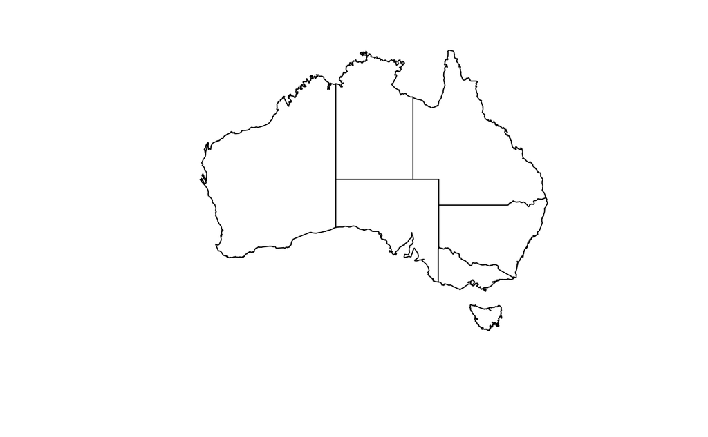

```r
oz()
```

But, if we want to plot it within the tidyverse we need to turn those points into a tibble. Let’s do that

```r
# get the lines for the map
oz_lines <- ozRegion()
```

`oz_lines` is a list. The third component is a list of x and y vectors that are long-lats for points along the oz coastline and states. (I hope).

So, we have to turn that into a tidy data frame much like you would get from map_data(). Which would look like:

```r
head(map_data("usa"))
```

|  | long | lat | group | order | region | subregion |
| --- | --- | --- | --- | --- | --- | --- |
| 1 | -101.4078 | 29.74224 | 1 | 1 | main | NA |
| 2 | -101.3906 | 29.74224 | 1 | 2 | main | NA |
| 3 | -101.3620 | 29.65056 | 1 | 3 | main | NA |
| 4 | -101.3505 | 29.63911 | 1 | 4 | main | NA |
| 5 | -101.3219 | 29.63338 | 1 | 5 | main | NA |
| 6 | -101.3047 | 29.64484 | 1 | 6 | main | NA |

So, we can parse `oz_lines` out like this:

```r
z <- oz_lines[[3]]
oz_tidy <- lapply(seq_along(z), function(i) {
  tibble(long = z[[i]]$x,
         lat = z[[i]]$y,
         group = i,
         order = 1:length(z[[i]]$x),
         region = as.character(i),
         subregion = NA)
  }) %>%
  bind_rows()
```

Now, plot that. We have to use geom_path rather than geom_polygon, because the things are stored as lines rather than as polygons.

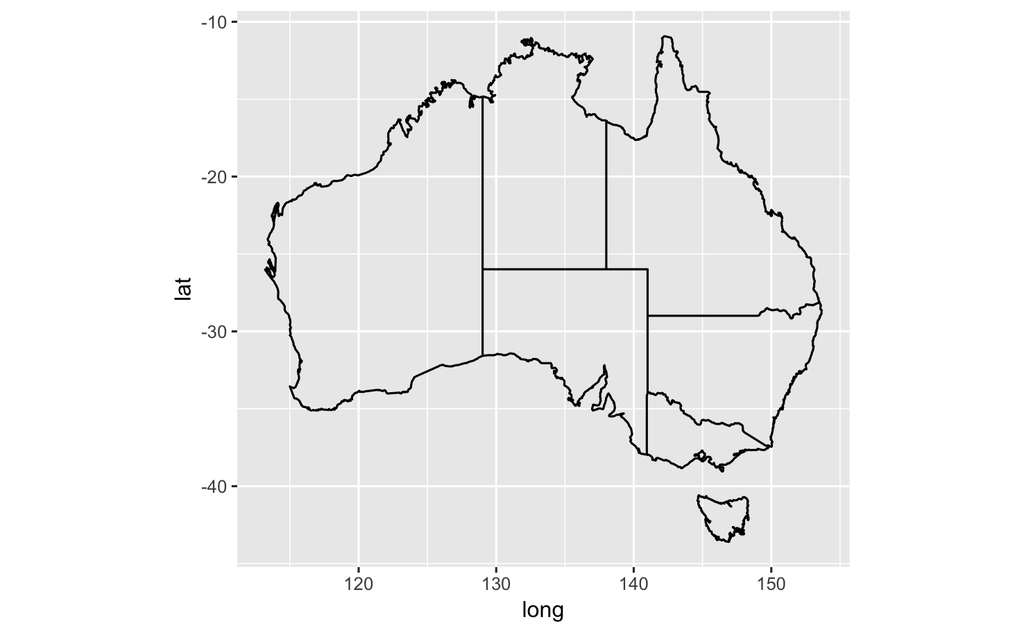

```r
ggplot(data = oz_tidy) +
  geom_path(aes(x = long, y = lat, group = group)) +
  coord_quickmap()
```

To see which pieces of the lines in the tibble correspond to which regions, we can color them by region:

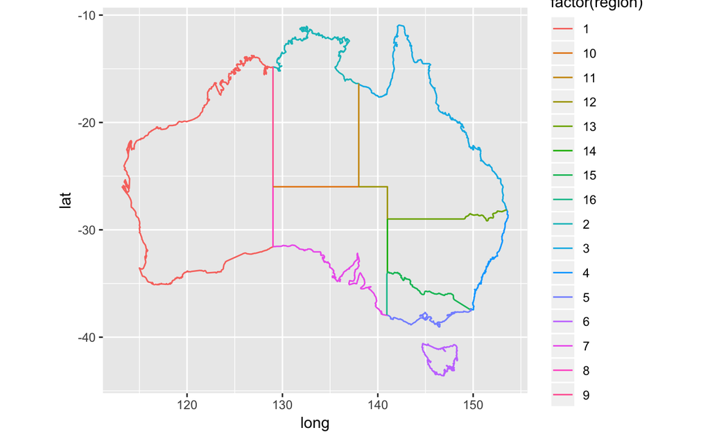

```r
ggplot(data = oz_tidy) +
  geom_path(aes(x = long, y = lat, group = group, colour = factor(region))) +
  coord_quickmap()
```